# Sensitivity Analysis for Pueblo

Project: Differential Gene Expression and Pulmonary Function in Vaping LatinX Adolescents Analyst: Trent Hawkins Investigator(s): Sunita Sharma, MD Report generated: October 26, 2022

# Introduction

The breakdown of study participants shows that 12 of the 13 (92%) vapers recruited for this study were from the Pueblo recruitment center. Overall, 21 subjects (42%) were recruited at the Pueblo center. We are concerned that this demographic imbalance could act as as a confounder or source of multicollinearity. The purpose of this report is to look at an analysis of only the participants recruited from the Pueblo center and compare it to the overall model containing all study participants to assess differences in estimates and significant gene composition between the models.

# Methods

To assess the difference in model outputs, the following model was fit in DESeq2 with all the recruited subjects and again, but only with the subjects from the Pueblo recruitment center. Likelihood Ratio Tests (LRTs) were implemented to test for gene significance and corrected with FDR $\le$ 0.05. For the purpose of this report, the model containing all subjects will be referred to as *Model A* and the model with only participants from the Pueblo recruitment center will be referred to as *Model P*.

$$Full \ Model \\ raw \ read \ count \sim
vape \ status + recruitment \ center + sex + age + ruv_1 +
ruv_2$$

$$Reduced \ Model \ (Vape \ Status) \\ raw
\ read \ count \sim recruitment \ center + sex + age + ruv_1 +
ruv_2$$

When fitting the model for only the subjects recruited in Pueblo, the *recruitment center* covariate is held constant, and therefore, not included in the model. Each of these models will test if *vape status* contributes significantly to gene expression.

To assess the difference in the models, the results will focus on genes with relatively low variability. To achieve a stable subset, a cutoff value of |Log<sub>2</sub>(Fold-Change)| > 2 will be used (see “sample12_sensitivity_report” for details). This report will present:

# Results

```r
#############Read in results###################
modA_res <- read_csv(here("DataProcessed/rna_seq/differential_expression/full_analysis/full_vape_res_2022_10_13.csv"))
modB_res <- read_csv(here("DataProcessed/rna_seq/differential_expression/pueblo_sensitivity/vape_res_pblo_2022_10_21.csv"))

#############Join results and get top 100 genes###################
AB_res <- left_join(modA_res, modB_res, by = c("ensg", "gene_name", "gene_type"), suffix = c(".modA", ".modB"))


######################### Filter for log-fold change (check) ###############################


#Make Tidy Results
AB_res <- AB_res %>%
  dplyr::mutate(fold_change_diff = log2FoldChange.modB - log2FoldChange.modA,
                fold_change_diff_p = ((log2FoldChange.modB - log2FoldChange.modA)/log2FoldChange.modA)*100) %>%
  dplyr::select(ensg, gene_name, gene_type, log2FoldChange.modA, log2FoldChange.modB, fold_change_diff, fold_change_diff_p, padj.modA, padj.modB) %>%
  dplyr::rename(Gene = ensg,
                Gene_Name = gene_name,
                Gene_Type = gene_type,
                Estimate_A = log2FoldChange.modA,
                Estimate_B = log2FoldChange.modB,
                Estimate_Difference = fold_change_diff,
                Estimate_P_Difference = fold_change_diff_p,
                FDR_A = padj.modA,
                FDR_B = padj.modB)

AB_res_no_cutoff <- AB_res
```

### Figure 1: Total Significant Genes in Models A & B

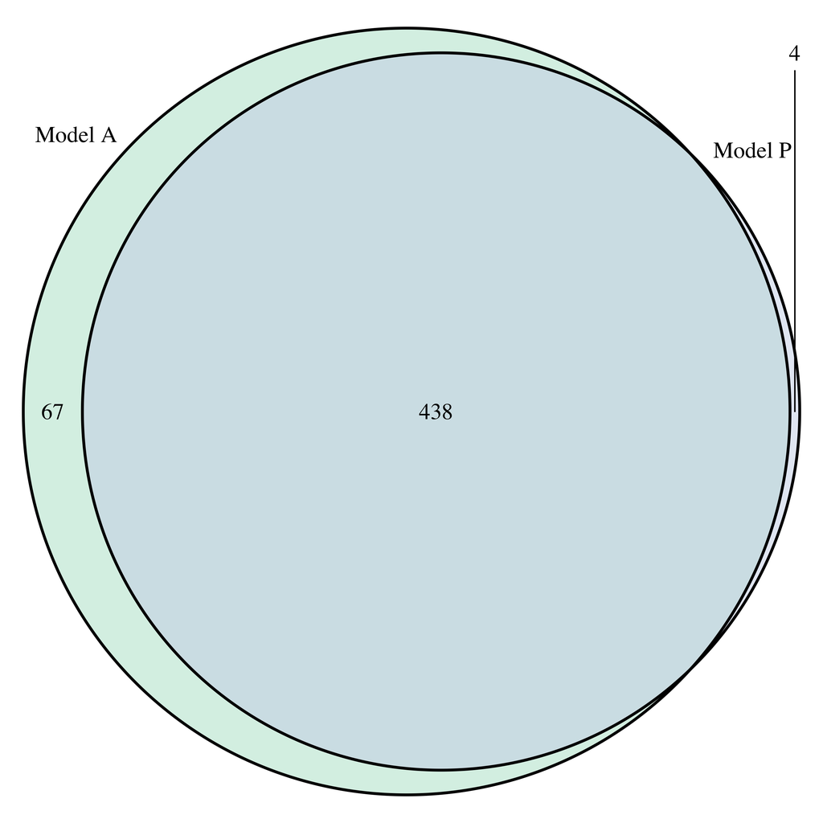

### Figure 2: Difference in Log<sub>2</sub>(Fold-Change) (Top 100 Genes)

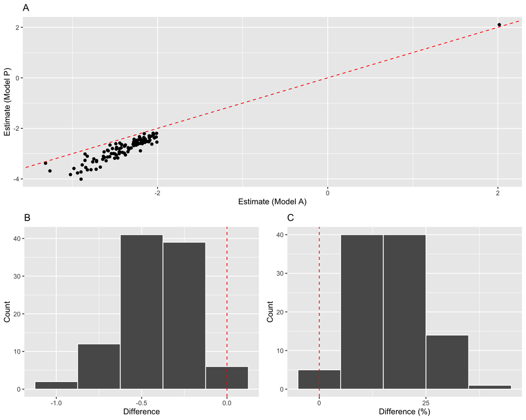

```r
#############Plots of change in log2fc##################
#Cutoff
AB_res <- AB_res %>%
  filter(abs(Estimate_A) > 2)
#subset the top 100
top_100_genes_AB <- AB_res %>% arrange(FDR_A) %>% .[1:100,]

#Scatter Plot
change_scatter <- top_100_genes_AB %>%
  ggplot(aes(x = Estimate_A, y = Estimate_B)) +
  geom_point(col = case_when(top_100_genes_AB$Estimate_A > 0 & top_100_genes_AB$Estimate_B < 0 ~ 'red',
                             top_100_genes_AB$Estimate_A < 0 & top_100_genes_AB$Estimate_B > 0 ~ 'red',
                             TRUE ~ 'black')) +
  geom_abline(intercept = 0, slope = 1, linetype = 2, col = 'red')+
  labs(x = "Estimate (Model A)",
       y = "Estimate (Model P)",
       title = "A")

#Histogram of difference
diff_hist <- top_100_genes_AB %>%
  ggplot(aes(x = Estimate_Difference)) +
  geom_histogram(col = 'white', binwidth = 0.25) +
  scale_x_continuous(breaks = seq(-1.5, 1.5, 0.5)) +
  geom_vline(xintercept = 0, linetype = 2, col = 'red') +
  labs(x = "Difference",
       y = "Count",
       title = "B")

#Histogram of % change
p_diff_hist <- top_100_genes_AB %>%
  ggplot(aes(x = Estimate_P_Difference)) +
  geom_histogram(col = 'white', binwidth = 10) +
  scale_x_continuous(breaks = seq(-100, 100, 25)) +
  geom_vline(xintercept = 0, linetype = 2, col = 'red') +
  labs(x = "Difference (%)",
       y = "Count",
       title = "C")

ggarrange(change_scatter, ggarrange(diff_hist, p_diff_hist, ncol = 2, nrow = 1, legend = "none"), nrow = 2, common.legend = T, legend = "bottom")
```

*Table 1: Top 10 Significant Genes Models A & p*

```r
top_100_genes_AB[1:10,] %>%
  dplyr::select(Gene, Gene_Name, Gene_Type, Estimate_A, Estimate_B, Estimate_Difference, Estimate_P_Difference, FDR_A, FDR_B) %>%
  mutate(FDR_A = if_else(FDR_A < 0.001, "< 0.001", as.character(round(FDR_A,3))),
         FDR_B = if_else(FDR_B < 0.001, "< 0.001", as.character(round(FDR_B,3))),
         Gene = gsub("\\..*", "", Gene)) %>%
  dplyr::rename("Ensemble ID" = Gene,
                "Gene Name" = Gene_Name,
                "Gene Type" = Gene_Type,
                "Log~2~(FC) (Mod A)" = Estimate_A,
                "Log~2~(FC) (Mod P)" = Estimate_B,
                "Log~2~(FC) Difference (P - A)" = Estimate_Difference,
                "Log~2~(FC) Difference (%)" = Estimate_P_Difference,
                "FDR (Mod A)" = FDR_A,
                "FDR (Mod P)" = FDR_B) %>%
  kablize(.,digits = 3)
```

| Ensemble ID | Gene Name | Gene Type | Log<sub>2</sub>(FC) (Mod A) | Log<sub>2</sub>(FC) (Mod P) | Log<sub>2</sub>(FC) Difference (P - A) | Log<sub>2</sub>(FC) Difference (%) | FDR (Mod A) | FDR (Mod P) |
| --- | --- | --- | --- | --- | --- | --- | --- | --- |
| ENSG00000188039 | NWD1 | protein_coding | -2.156 | -2.210 | -0.055 | 2.542 | < 0.001 | < 0.001 |
| ENSG00000118997 | DNAH7 | protein_coding | -2.071 | -2.307 | -0.236 | 11.391 | < 0.001 | < 0.001 |
| ENSG00000105519 | CAPS | protein_coding | -2.011 | -2.196 | -0.185 | 9.180 | < 0.001 | < 0.001 |
| ENSG00000287189 | AL121956.6 | lncRNA | -2.825 | -3.101 | -0.276 | 9.765 | < 0.001 | < 0.001 |
| ENSG00000174844 | DNAH12 | protein_coding | -2.232 | -2.625 | -0.394 | 17.637 | < 0.001 | < 0.001 |
| ENSG00000154479 | CCDC173 | protein_coding | -2.422 | -2.639 | -0.217 | 8.956 | < 0.001 | < 0.001 |
| ENSG00000163263 | C1orf189 | protein_coding | -2.144 | -2.425 | -0.281 | 13.094 | < 0.001 | < 0.001 |
| ENSG00000197653 | DNAH10 | protein_coding | -2.381 | -2.675 | -0.293 | 12.317 | < 0.001 | < 0.001 |
| ENSG00000186976 | EFCAB6 | protein_coding | -2.243 | -2.470 | -0.227 | 10.107 | < 0.001 | < 0.001 |
| ENSG00000172955 | ADH6 | protein_coding | -2.852 | -3.266 | -0.414 | 14.520 | < 0.001 | < 0.001 |

These results demonstrate that estimates systematically decrease when looking only at subjects from Pueblo. That effect does not make a large difference in the number of significant genes or the direction of their effect.

### Figure 3: Difference in Log<sub>2</sub>(Fold-Change) (Top 2000 Genes)

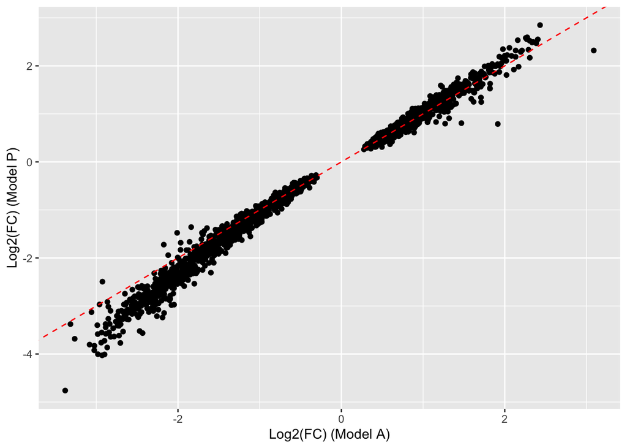

```r
#Get the top 2000 genes
top_1000 <- AB_res_no_cutoff[1:2000,]

#Scatter Plot
change_scatter <- top_1000 %>%
  ggplot(aes(x = Estimate_A, y = Estimate_B)) +
  geom_point() +
  geom_abline(aes(intercept = 0, slope = 1, col = "Equal Estimates"), linetype = 2, col = 'red')+
  labs(x = "Log2(FC) (Model A)",
       y = "Log2(FC) (Model P)") +
  scale_x_continuous(breaks = seq(-10,10,2)) +
  scale_y_continuous(breaks = seq(-10,10,2)) +
  scale_color_manual(name = "Guides", values = c("Equal Log2(FC)" = "red"))
change_scatter
```

There is a small amount of variability present in the estimates; however, most of the estimates are clustered around the line representing equal estimates.

### Figure 4: -log<sub>10</sub>(p-value) Model A vs. Model P

Figure 4 similarly visualizes the trend by plotting -log<sub>10</sub>(p-value) for each of the models plotted against each other.

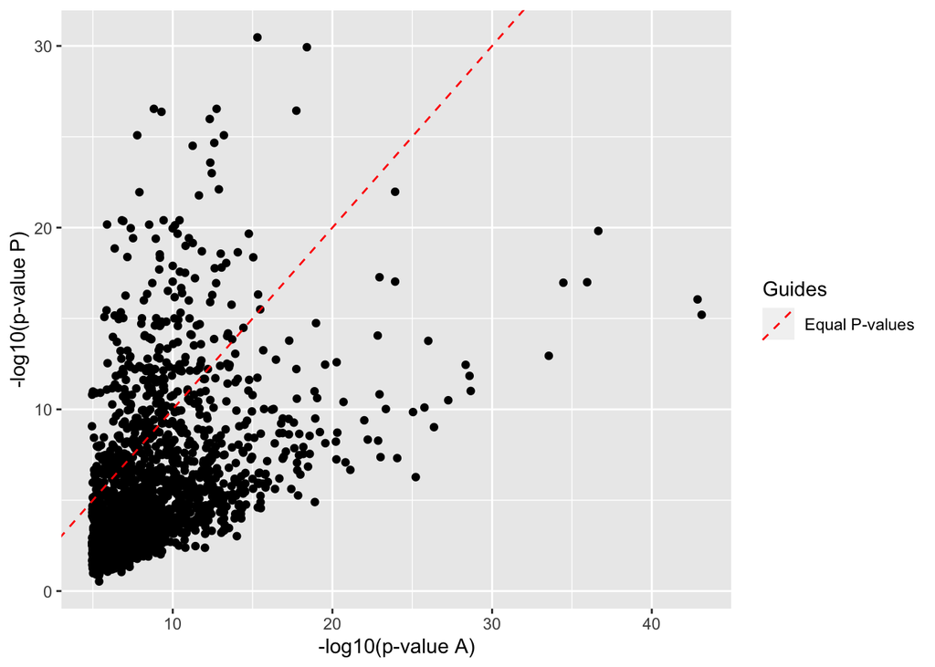

```r
top_1000 %>%
  ggplot(aes(x = -log10(FDR_A), y = -log10(FDR_B))) +
  geom_point() +
  geom_abline(aes(intercept = 0, slope = 1, col = 'Equal P-values'), linetype = 2)+
  scale_color_manual(name = "Guides", values = c("Equal P-values" = "red")) +
  scale_y_continuous(breaks = seq(0,40,10)) +
  labs(x = "-log10(p-value A)",
       y = "-log10(p-value P)")
```

Excluding subjects that are not from Pueblo from the model additionally inflates p-values. P-values are already very small, so a small increase in p-values does not change the overall composition of significant genes.

# Conclusion